# Exploration

# Introduction

The purpose of this study is to compare the relative efficacy of *explicit* (ie. visually-salient text or images that serve instructional purpose) and *implicit* (ie. task and question structure) scaffolding for an unconventional statistical graph. We hypothesize that implicit techniques—specifically presenting a task that forms a **mental impasse** for the reader—will be more supportive of correct graph interpretation than explicit graph-reading instructions. We base this hypothesis on prior observation and experimental work (Fox & Hollan, *in preparation*) which revealed that when presented with an unconventional graph with structural elements (ie. axes and grid) that resembled conventional graphs, learners did not always realize they did not understand how the graph was meant to be read. We propose that prior knoweldge of conventional graph systems acts as a form of “graphical fixedness”, that learners must overcome to form correct mental models for new representational systems.

# Methods

## Design

We utilized a 3 (explicit scaffold: none, text/image, interactive) X 2 (implicit scaffold: none, impasse) between-subjects factorial design, with response time and score (max = 15) as dependent variables.

## Participants

**37 students** (`70` % female) registered as STEM majors at a public university in the United States participated in exchange for course credit (age: `18` - `27` years).

## Measures

### Response Accuracy

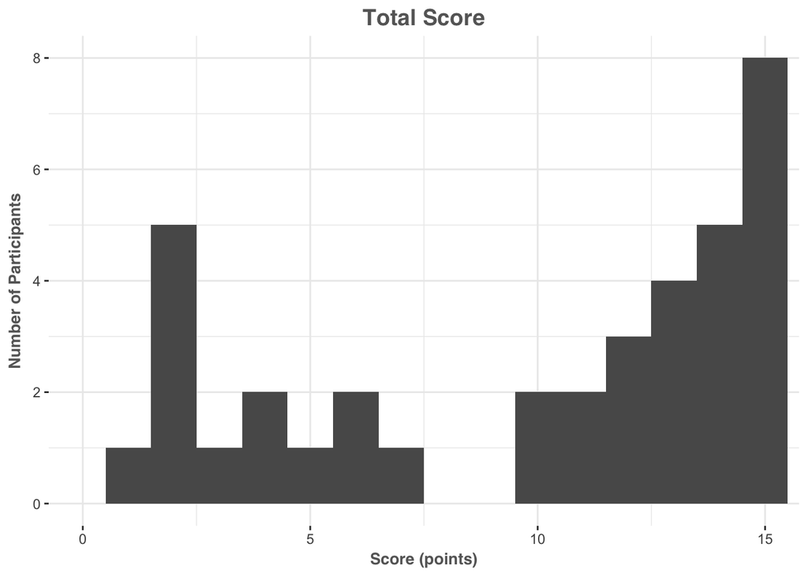

A Shapiro-Wilk test for normality yielded a value of `0.8332824`, p = `6.5615004\times 10^{-5}` suggesting that the distibution is significantly non-normal.

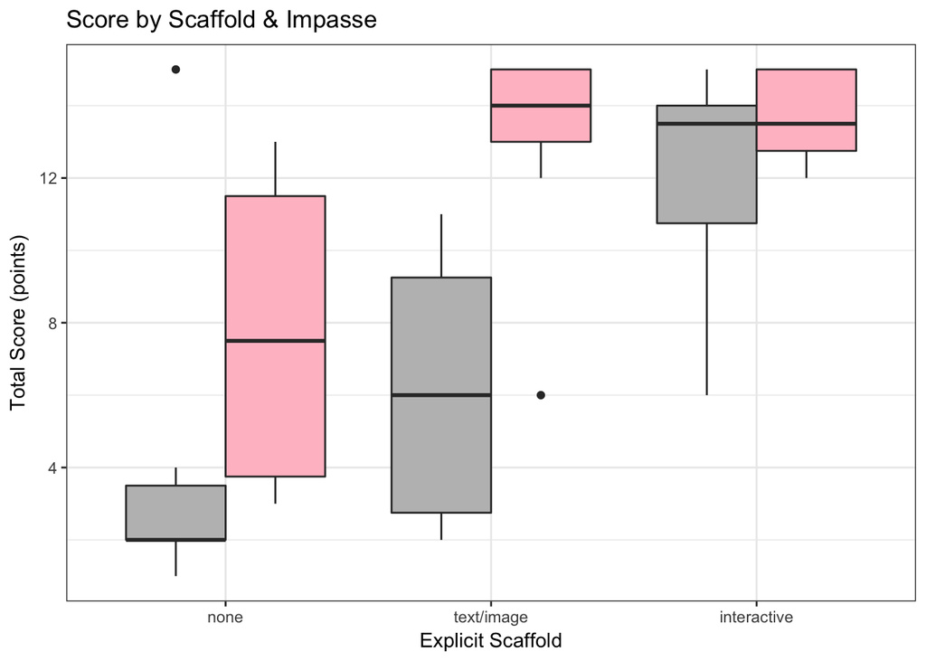

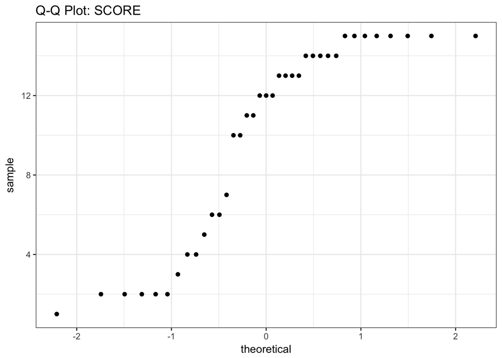

### Response Latency

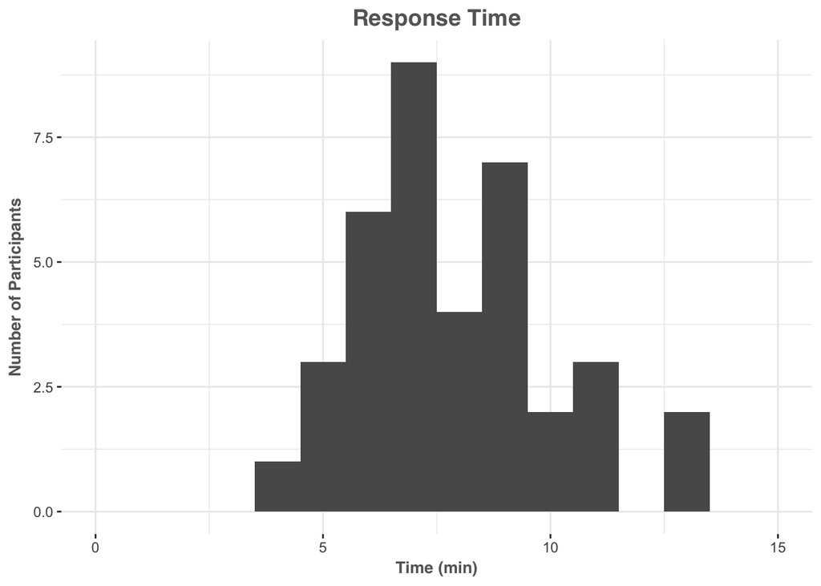

A Shapiro-Wilk test for normality yielded a value of `0.9602912`, p = `0.206374` suggesting that the data are from a normally-distributed population.

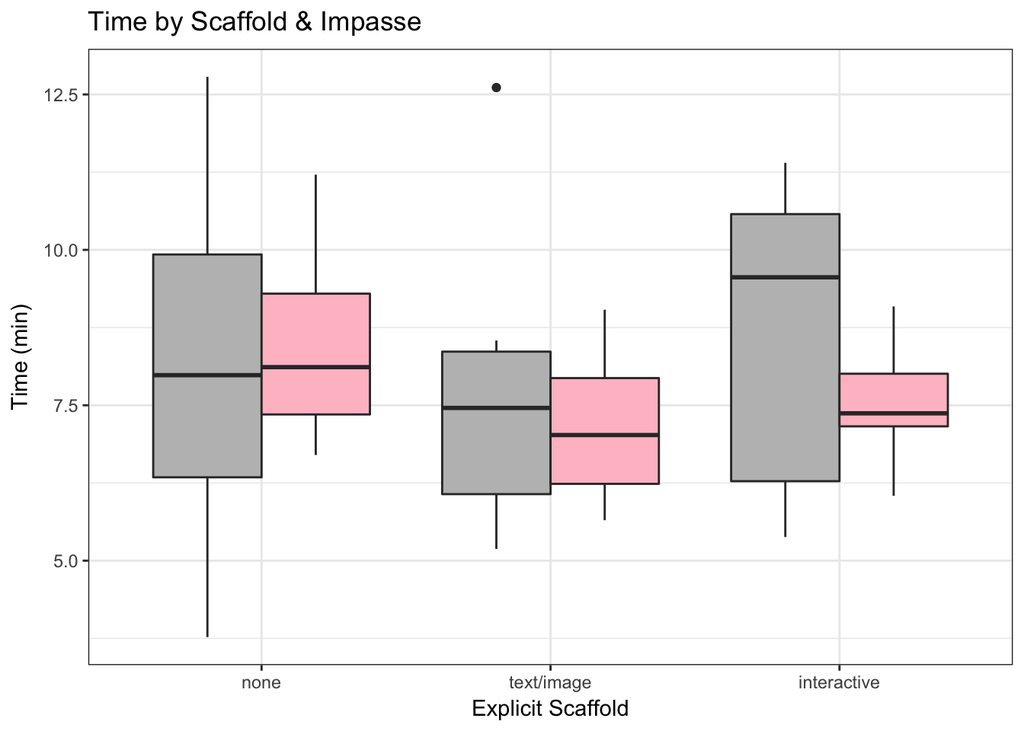

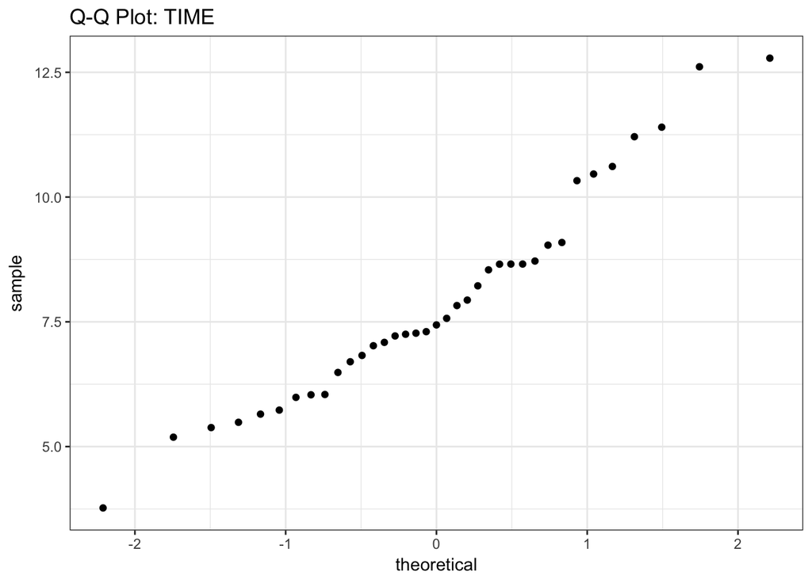

# Results

### Response Accuracy

| IMPASSE | EXPLICIT Scaffold none mean | EXPLICIT Scaffold none sd | EXPLICIT Scaffold text/image mean | EXPLICIT Scaffold text/image sd | EXPLICIT Scaffold interactive mean | EXPLICIT Scaffold interactive sd |
| --- | --- | --- | --- | --- | --- | --- |
| none | 4.3 | 5.3 | 6.2 | 3.9 | 12.0 | 3.4 |
| impasse | 7.8 | 5.0 | 13.0 | 3.3 | 13.6 | 1.3 |

```
## Anova Table (Type II tests)
##
## Response: triangular_score
##                  Sum Sq Df F value    Pr(>F)
## explicit         245.29  1 17.4680 0.0002016 ***
## impasse          143.35  1 10.2082 0.0030731 **
## explicit:impasse   8.34  1  0.5942 0.4463001
## Residuals        463.39 33
## ---
## Signif. codes:  0 '***' 0.001 '**' 0.01 '*' 0.05 '.' 0.1 ' ' 1
```

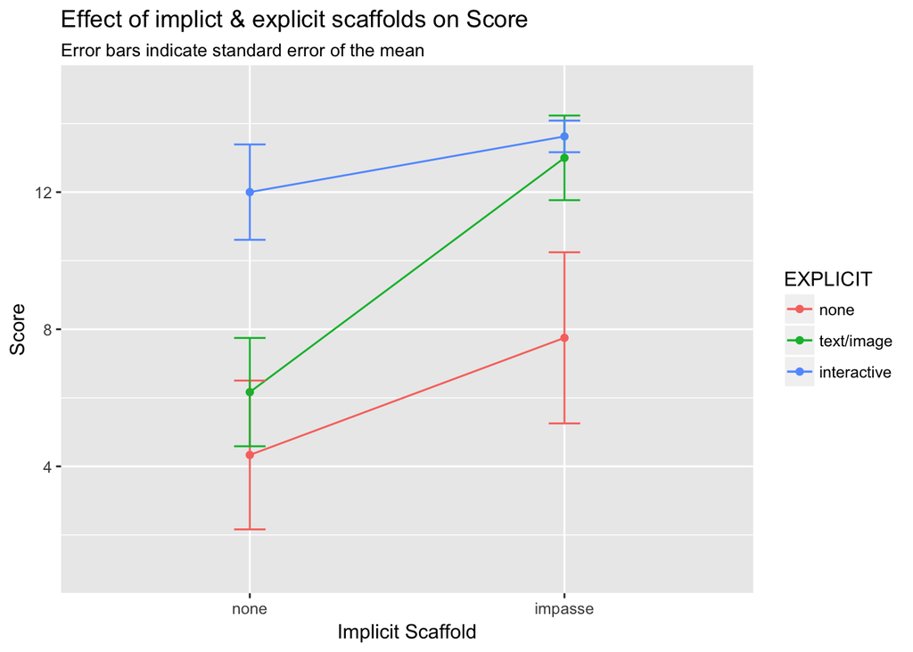

### Response Time

| IMPASSE | EXPLICIT Scaffold none mean | EXPLICIT Scaffold none sd | EXPLICIT Scaffold text/image mean | EXPLICIT Scaffold text/image sd | EXPLICIT Scaffold interactive mean | EXPLICIT Scaffold interactive sd |
| --- | --- | --- | --- | --- | --- | --- |
| none | 8.15 | 3.19 | 7.83 | 2.66 | 8.67 | 2.66 |
| impasse | 8.53 | 1.96 | 7.15 | 1.28 | 7.52 | 0.92 |

```
## Anova Table (Type II tests)
##
## Response: tt_min
##                   Sum Sq Df F value Pr(>F)
## explicit           0.071  1  0.0152 0.9025
## impasse            3.354  1  0.7210 0.4019
## explicit:impasse   2.461  1  0.5291 0.4721
## Residuals        153.502 33
```

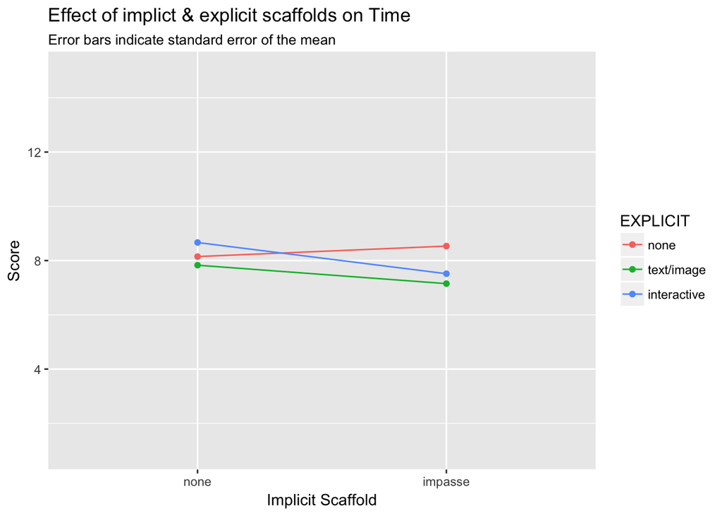

[output not shown]